# Project : Data Wrangling

## Topic : WeRateDogs

### by Hassan Abbas Jaffri

```python
import pandas as pd
import numpy as np
import requests
import tweepy
import os
import json
import time
import re
import matplotlib.pyplot as plt
import seaborn as sb
%matplotlib inline
```

## Gathering Data :

**Gathering Twitter Archive Data**

```python
twitter_archive = pd.read_csv('twitter-archive-enhanced.csv')
```

```python
twitter_archive.head()
```

|  | tweet_id | in_reply_to_status_id | in_reply_to_user_id | timestamp | source | text | retweeted_status_id | retweeted_status_user_id | retweeted_status_timestamp | expanded_urls | rating_numerator | rating_denominator | name | doggo | floofer | pupper | puppo |
| --- | --- | --- | --- | --- | --- | --- | --- | --- | --- | --- | --- | --- | --- | --- | --- | --- | --- |
| 0 | 892420643555336193 | NaN | NaN | 2017-08-01 16:23:56 +0000 | <a href="http://twitter.com/download/iphone" r... | This is Phineas. He's a mystical boy. Only eve... | NaN | NaN | NaN | https://twitter.com/dog_rates/status/892420643... | 13 | 10 | Phineas | None | None | None | None |
| 1 | 892177421306343426 | NaN | NaN | 2017-08-01 00:17:27 +0000 | <a href="http://twitter.com/download/iphone" r... | This is Tilly. She's just checking pup on you.... | NaN | NaN | NaN | https://twitter.com/dog_rates/status/892177421... | 13 | 10 | Tilly | None | None | None | None |
| 2 | 891815181378084864 | NaN | NaN | 2017-07-31 00:18:03 +0000 | <a href="http://twitter.com/download/iphone" r... | This is Archie. He is a rare Norwegian Pouncin... | NaN | NaN | NaN | https://twitter.com/dog_rates/status/891815181... | 12 | 10 | Archie | None | None | None | None |
| 3 | 891689557279858688 | NaN | NaN | 2017-07-30 15:58:51 +0000 | <a href="http://twitter.com/download/iphone" r... | This is Darla. She commenced a snooze mid meal... | NaN | NaN | NaN | https://twitter.com/dog_rates/status/891689557... | 13 | 10 | Darla | None | None | None | None |
| 4 | 891327558926688256 | NaN | NaN | 2017-07-29 16:00:24 +0000 | <a href="http://twitter.com/download/iphone" r... | This is Franklin. He would like you to stop ca... | NaN | NaN | NaN | https://twitter.com/dog_rates/status/891327558... | 12 | 10 | Franklin | None | None | None | None |

**Gathering Images Predictions data**

```python
url = "https://d17h27t6h515a5.cloudfront.net/topher/2017/August/599fd2ad_image-predictions/image-predictions.tsv"
response = requests.get(url)
with open(os.path.join('image_predictions.tsv'), mode='wb') as file:
    file.write(response.content)
```

```python
image_predictions = pd.read_csv('image_predictions.tsv', sep='\t')
```

```python
image_predictions.head()
```

|  | tweet_id | jpg_url | img_num | p1 | p1_conf | p1_dog | p2 | p2_conf | p2_dog | p3 | p3_conf | p3_dog |
| --- | --- | --- | --- | --- | --- | --- | --- | --- | --- | --- | --- | --- |
| 0 | 666020888022790149 | https://pbs.twimg.com/media/CT4udn0WwAA0aMy.jpg | 1 | Welsh_springer_spaniel | 0.465074 | True | collie | 0.156665 | True | Shetland_sheepdog | 0.061428 | True |
| 1 | 666029285002620928 | https://pbs.twimg.com/media/CT42GRgUYAA5iDo.jpg | 1 | redbone | 0.506826 | True | miniature_pinscher | 0.074192 | True | Rhodesian_ridgeback | 0.072010 | True |
| 2 | 666033412701032449 | https://pbs.twimg.com/media/CT4521TWwAEvMyu.jpg | 1 | German_shepherd | 0.596461 | True | malinois | 0.138584 | True | bloodhound | 0.116197 | True |
| 3 | 666044226329800704 | https://pbs.twimg.com/media/CT5Dr8HUEAA-lEu.jpg | 1 | Rhodesian_ridgeback | 0.408143 | True | redbone | 0.360687 | True | miniature_pinscher | 0.222752 | True |
| 4 | 666049248165822465 | https://pbs.twimg.com/media/CT5IQmsXIAAKY4A.jpg | 1 | miniature_pinscher | 0.560311 | True | Rottweiler | 0.243682 | True | Doberman | 0.154629 | True |

**Getting Twitter API Data**

```python
tweets_data = []
with open('tweet-json.txt') as file:
    for line in file:
        try:
            tweet = json.loads(line)
            tweets_data.append(tweet)
        except:
            continue
df_api = pd.DataFrame(tweets_data, columns=list(tweets_data[0].keys()))
```

```python
tweet_df = df_api[['id', 'retweet_count', 'favorite_count']]
```

```python
tweet_df.head()
```

|  | id | retweet_count | favorite_count |
| --- | --- | --- | --- |
| 0 | 892420643555336193 | 8853 | 39467 |
| 1 | 892177421306343426 | 6514 | 33819 |
| 2 | 891815181378084864 | 4328 | 25461 |
| 3 | 891689557279858688 | 8964 | 42908 |
| 4 | 891327558926688256 | 9774 | 41048 |

```python
tweet_df.to_csv("tweet_json.csv")
```

```python
twitter_archive_clean = twitter_archive.copy()
image_predictions_clean = image_predictions.copy()
tweet_df_clean = tweet_df.copy()
```

## Assessing Data :

**Visual Assessment**

```python
twitter_archive_clean.sample(50)
```

|  | tweet_id | in_reply_to_status_id | in_reply_to_user_id | timestamp | source | text | retweeted_status_id | retweeted_status_user_id | retweeted_status_timestamp | expanded_urls | rating_numerator | rating_denominator | name | doggo | floofer | pupper | puppo |
| --- | --- | --- | --- | --- | --- | --- | --- | --- | --- | --- | --- | --- | --- | --- | --- | --- | --- |
| 714 | 784057939640352768 | NaN | NaN | 2016-10-06 15:49:14 +0000 | <a href="http://vine.co" rel="nofollow">Vine -... | This is Balto. He's very content. Legendary to... | NaN | NaN | NaN | https://vine.co/v/5gKxeUpuKEr | 12 | 10 | Balto | None | None | None | None |
| 1885 | 674793399141146624 | 6.717299e+17 | 4.196984e+09 | 2015-12-10 03:30:58 +0000 | <a href="http://twitter.com/download/iphone" r... | I have found another. 13/10 https://t.co/HwroP... | NaN | NaN | NaN | https://twitter.com/dog_rates/status/674793399... | 13 | 10 | None | None | None | None | None |
| 534 | 807106840509214720 | NaN | NaN | 2016-12-09 06:17:20 +0000 | <a href="http://twitter.com/download/iphone" r... | This is Stephan. He just wants to help. 13/10 ... | NaN | NaN | NaN | https://twitter.com/dog_rates/status/807106840... | 13 | 10 | Stephan | None | None | None | None |
| 1045 | 743595368194129920 | NaN | NaN | 2016-06-17 00:05:25 +0000 | <a href="http://twitter.com/download/iphone" r... | This is Harold. He looks slippery af. Probably... | NaN | NaN | NaN | https://twitter.com/dog_rates/status/743595368... | 7 | 10 | Harold | None | None | None | None |
| 2261 | 667549055577362432 | NaN | NaN | 2015-11-20 03:44:31 +0000 | <a href="http://twitter.com" rel="nofollow">Tw... | Never seen dog like this. Breathes heavy. Tilt... | NaN | NaN | NaN | https://twitter.com/dog_rates/status/667549055... | 1 | 10 | None | None | None | None | None |
| 354 | 831262627380748289 | NaN | NaN | 2017-02-13 22:03:49 +0000 | <a href="http://twitter.com/download/iphone" r... | This is Tucker. He's feeling h*ckin festive an... | NaN | NaN | NaN | https://twitter.com/dog_rates/status/831262627... | 12 | 10 | Tucker | None | None | None | None |
| 299 | 836989968035819520 | NaN | NaN | 2017-03-01 17:22:13 +0000 | <a href="http://twitter.com/download/iphone" r... | This is Mookie. He really enjoys shopping but ... | NaN | NaN | NaN | https://twitter.com/dog_rates/status/836989968... | 12 | 10 | Mookie | None | None | None | None |
| 1566 | 687841446767013888 | NaN | NaN | 2016-01-15 03:39:15 +0000 | <a href="http://vine.co" rel="nofollow">Vine -... | 13/10 I can't stop watching this (vid by @k8ly... | NaN | NaN | NaN | https://vine.co/v/iOWwUPH1hrw | 13 | 10 | None | None | None | None | None |
| 1632 | 684460069371654144 | NaN | NaN | 2016-01-05 19:42:51 +0000 | <a href="http://twitter.com/download/iphone" r... | This is Jeph. He's a Western Sagittarius Dookm... | NaN | NaN | NaN | https://twitter.com/dog_rates/status/684460069... | 10 | 10 | Jeph | None | None | None | None |
| 1708 | 680798457301471234 | NaN | NaN | 2015-12-26 17:12:55 +0000 | <a href="http://twitter.com/download/iphone" r... | Say hello to Moofasa. He must be a powerful do... | NaN | NaN | NaN | https://twitter.com/dog_rates/status/680798457... | 6 | 10 | Moofasa | None | None | None | None |
| 77 | 877736472329191424 | NaN | NaN | 2017-06-22 03:54:17 +0000 | <a href="http://twitter.com/download/iphone" r... | This is Aja. She was just told she's a good do... | NaN | NaN | NaN | https://twitter.com/dog_rates/status/877736472... | 13 | 10 | Aja | None | None | None | None |
| 2339 | 666102155909144576 | NaN | NaN | 2015-11-16 03:55:04 +0000 | <a href="http://twitter.com/download/iphone" r... | Oh my. Here you are seeing an Adobe Setter giv... | NaN | NaN | NaN | https://twitter.com/dog_rates/status/666102155... | 11 | 10 | None | None | None | None | None |
| 2025 | 671882082306625538 | NaN | NaN | 2015-12-02 02:42:26 +0000 | <a href="http://twitter.com/download/iphone" r... | This is Batdog. He's sleeping now but when he ... | NaN | NaN | NaN | https://twitter.com/dog_rates/status/671882082... | 11 | 10 | Batdog | None | None | None | None |
| 2290 | 667171260800061440 | NaN | NaN | 2015-11-19 02:43:18 +0000 | <a href="http://twitter.com/download/iphone" r... | Say hello to Kenneth. He likes Reese's Puffs. ... | NaN | NaN | NaN | https://twitter.com/dog_rates/status/667171260... | 10 | 10 | Kenneth | None | None | None | None |
| 121 | 869596645499047938 | NaN | NaN | 2017-05-30 16:49:31 +0000 | <a href="http://twitter.com/download/iphone" r... | This is Scout. He just graduated. Officially a... | NaN | NaN | NaN | https://twitter.com/dog_rates/status/869596645... | 12 | 10 | Scout | doggo | None | None | None |
| 1765 | 678410210315247616 | NaN | NaN | 2015-12-20 03:02:53 +0000 | <a href="http://twitter.com/download/iphone" r... | Say hello to Jerome. He can shoot french fries... | NaN | NaN | NaN | https://twitter.com/dog_rates/status/678410210... | 10 | 10 | Jerome | None | None | None | None |
| 900 | 758740312047005698 | NaN | NaN | 2016-07-28 19:06:01 +0000 | <a href="http://twitter.com/download/iphone" r... | Meet Boston. He's worried because his tongue w... | NaN | NaN | NaN | https://twitter.com/dog_rates/status/758740312... | 12 | 10 | Boston | None | None | None | None |
| 712 | 784431430411685888 | NaN | NaN | 2016-10-07 16:33:21 +0000 | <a href="http://twitter.com/download/iphone" r... | This is Stormy. He's curly af. Already pupared... | NaN | NaN | NaN | https://twitter.com/dog_rates/status/784431430... | 12 | 10 | Stormy | None | None | None | None |
| 1098 | 736010884653420544 | NaN | NaN | 2016-05-27 01:47:23 +0000 | <a href="http://twitter.com/download/iphone" r... | Right after you graduate vs when you remember ... | NaN | NaN | NaN | https://twitter.com/dog_rates/status/736010884... | 10 | 10 | None | None | None | None | None |
| 2 | 891815181378084864 | NaN | NaN | 2017-07-31 00:18:03 +0000 | <a href="http://twitter.com/download/iphone" r... | This is Archie. He is a rare Norwegian Pouncin... | NaN | NaN | NaN | https://twitter.com/dog_rates/status/891815181... | 12 | 10 | Archie | None | None | None | None |
| 1274 | 709198395643068416 | NaN | NaN | 2016-03-14 02:04:08 +0000 | <a href="http://twitter.com/download/iphone" r... | From left to right:\nCletus, Jerome, Alejandro... | NaN | NaN | NaN | https://twitter.com/dog_rates/status/709198395... | 45 | 50 | None | None | None | None | None |
| 653 | 792050063153438720 | NaN | NaN | 2016-10-28 17:07:05 +0000 | <a href="http://twitter.com/download/iphone" r... | This is Remus. He's a mop that came to life. C... | NaN | NaN | NaN | https://twitter.com/dog_rates/status/792050063... | 11 | 10 | Remus | None | None | None | None |
| 845 | 766423258543644672 | NaN | NaN | 2016-08-18 23:55:18 +0000 | <a href="http://twitter.com/download/iphone" r... | This is Shadoe. Her tongue flies out of her mo... | NaN | NaN | NaN | https://twitter.com/dog_rates/status/766423258... | 9 | 10 | Shadoe | None | None | None | None |
| 92 | 874296783580663808 | NaN | NaN | 2017-06-12 16:06:11 +0000 | <a href="http://twitter.com/download/iphone" r... | This is Jed. He may be the fanciest pupper in ... | NaN | NaN | NaN | https://twitter.com/dog_rates/status/874296783... | 13 | 10 | Jed | None | None | pupper | None |
| 2020 | 672095186491711488 | NaN | NaN | 2015-12-02 16:49:14 +0000 | <a href="http://twitter.com/download/iphone" r... | This is Tuco. That's the toast that killed his... | NaN | NaN | NaN | https://twitter.com/dog_rates/status/672095186... | 9 | 10 | Tuco | None | None | None | None |
| 84 | 876484053909872640 | NaN | NaN | 2017-06-18 16:57:37 +0000 | <a href="http://twitter.com/download/iphone" r... | This is Benedict. He wants to thank you for th... | NaN | NaN | NaN | https://twitter.com/dog_rates/status/876484053... | 13 | 10 | Benedict | None | None | None | None |
| 955 | 751598357617971201 | NaN | NaN | 2016-07-09 02:06:27 +0000 | <a href="http://twitter.com/download/iphone" r... | This is Toby. A cat got his tongue. 13/10 ador... | NaN | NaN | NaN | https://twitter.com/dog_rates/status/751598357... | 13 | 10 | Toby | None | None | None | None |
| 69 | 879050749262655488 | NaN | NaN | 2017-06-25 18:56:45 +0000 | <a href="http://twitter.com/download/iphone" r... | This is Steven. He has trouble relating to oth... | NaN | NaN | NaN | https://twitter.com/dog_rates/status/879050749... | 11 | 10 | Steven | None | None | None | None |
| 190 | 855857698524602368 | NaN | NaN | 2017-04-22 18:55:51 +0000 | <a href="http://twitter.com/download/iphone" r... | HE'S LIKE "WAIT A MINUTE I'M AN ANIMAL THIS IS... | NaN | NaN | NaN | https://twitter.com/perfy/status/8558573181681... | 13 | 10 | None | None | None | None | None |
| 2349 | 666051853826850816 | NaN | NaN | 2015-11-16 00:35:11 +0000 | <a href="http://twitter.com/download/iphone" r... | This is an odd dog. Hard on the outside but lo... | NaN | NaN | NaN | https://twitter.com/dog_rates/status/666051853... | 2 | 10 | an | None | None | None | None |
| 2117 | 670421925039075328 | NaN | NaN | 2015-11-28 02:00:17 +0000 | <a href="http://twitter.com/download/iphone" r... | Meet Herb. 12/10 https://t.co/tLRyYvCci3 | NaN | NaN | NaN | https://twitter.com/dog_rates/status/670421925... | 12 | 10 | Herb | None | None | None | None |
| 1811 | 676819651066732545 | NaN | NaN | 2015-12-15 17:42:34 +0000 | <a href="http://twitter.com/download/iphone" r... | Watch out Airbud. This pupper is also good at ... | NaN | NaN | NaN | https://twitter.com/dog_rates/status/676819651... | 12 | 10 | None | None | None | pupper | None |
| 1940 | 673716320723169284 | 6.737159e+17 | 4.196984e+09 | 2015-12-07 04:11:02 +0000 | <a href="http://twitter.com/download/iphone" r... | The millennials have spoken and we've decided ... | NaN | NaN | NaN | NaN | 1 | 10 | None | None | None | None | None |
| 48 | 882992080364220416 | NaN | NaN | 2017-07-06 15:58:11 +0000 | <a href="http://twitter.com/download/iphone" r... | This is Rusty. He wasn't ready for the first p... | NaN | NaN | NaN | https://twitter.com/dog_rates/status/882992080... | 13 | 10 | Rusty | None | None | None | None |
| 1605 | 685681090388975616 | 6.855479e+17 | 4.196984e+09 | 2016-01-09 04:34:45 +0000 | <a href="http://twitter.com/download/iphone" r... | Jack deserves another round of applause. If yo... | NaN | NaN | NaN | NaN | 14 | 10 | None | None | None | None | None |
| 1307 | 707315916783140866 | NaN | NaN | 2016-03-08 21:23:50 +0000 | <a href="http://twitter.com/download/iphone" r... | This is Finnegus. He's trapped in a snow globe... | NaN | NaN | NaN | https://twitter.com/dog_rates/status/707315916... | 10 | 10 | Finnegus | None | None | pupper | None |
| 344 | 832032802820481025 | NaN | NaN | 2017-02-16 01:04:13 +0000 | <a href="http://twitter.com/download/iphone" r... | This is Miguel. He was the only remaining dogg... | NaN | NaN | NaN | https://www.petfinder.com/petdetail/34918210,h... | 12 | 10 | Miguel | doggo | None | None | None |
| 2009 | 672254177670729728 | NaN | NaN | 2015-12-03 03:21:00 +0000 | <a href="http://twitter.com/download/iphone" r... | This is Rolf. He's having the time of his life... | NaN | NaN | NaN | https://twitter.com/dog_rates/status/672254177... | 11 | 10 | Rolf | None | None | pupper | None |
| 2332 | 666345417576210432 | NaN | NaN | 2015-11-16 20:01:42 +0000 | <a href="http://twitter.com/download/iphone" r... | Look at this jokester thinking seat belt laws ... | NaN | NaN | NaN | https://twitter.com/dog_rates/status/666345417... | 10 | 10 | None | None | None | None | None |
| 67 | 879376492567855104 | NaN | NaN | 2017-06-26 16:31:08 +0000 | <a href="http://twitter.com/download/iphone" r... | This is Jack AKA Stephen Furry. You're not sco... | NaN | NaN | NaN | https://twitter.com/dog_rates/status/879376492... | 12 | 10 | Jack | None | None | None | None |
| 1712 | 680494726643068929 | NaN | NaN | 2015-12-25 21:06:00 +0000 | <a href="http://twitter.com/download/iphone" r... | Here we have uncovered an entire battalion of ... | NaN | NaN | NaN | https://twitter.com/dog_rates/status/680494726... | 26 | 10 | None | None | None | None | None |
| 136 | 866334964761202691 | NaN | NaN | 2017-05-21 16:48:45 +0000 | <a href="http://twitter.com/download/iphone" r... | This is Coco. At first I thought she was a clo... | NaN | NaN | NaN | https://twitter.com/dog_rates/status/866334964... | 12 | 10 | Coco | None | None | None | None |
| 948 | 752334515931054080 | NaN | NaN | 2016-07-11 02:51:40 +0000 | <a href="http://twitter.com/download/iphone" r... | Here's a doggo trying to catch some fish. 8/10... | NaN | NaN | NaN | https://twitter.com/dog_rates/status/752334515... | 8 | 10 | None | doggo | None | None | None |
| 1982 | 672968025906282496 | NaN | NaN | 2015-12-05 02:37:35 +0000 | <a href="http://twitter.com/download/iphone" r... | This is Gustaf. He's a purebred Chevy Equinox.... | NaN | NaN | NaN | https://twitter.com/dog_rates/status/672968025... | 11 | 10 | Gustaf | None | None | None | None |
| 1506 | 691756958957883396 | NaN | NaN | 2016-01-25 22:58:05 +0000 | <a href="http://twitter.com/download/iphone" r... | THE BRITISH ARE COMING\nTHE BRITISH ARE COMING... | NaN | NaN | NaN | https://twitter.com/dog_rates/status/691756958... | 10 | 10 | None | None | None | None | None |
| 25 | 887101392804085760 | NaN | NaN | 2017-07-18 00:07:08 +0000 | <a href="http://twitter.com/download/iphone" r... | This... is a Jubilant Antarctic House Bear. We... | NaN | NaN | NaN | https://twitter.com/dog_rates/status/887101392... | 12 | 10 | None | None | None | None | None |
| 1222 | 714258258790387713 | NaN | NaN | 2016-03-28 01:10:13 +0000 | <a href="http://twitter.com/download/iphone" r... | Meet Travis and Flurp. Travis is pretty chill ... | NaN | NaN | NaN | https://twitter.com/dog_rates/status/714258258... | 10 | 10 | Travis | None | None | None | None |
| 674 | 789599242079838210 | NaN | NaN | 2016-10-21 22:48:24 +0000 | <a href="http://twitter.com/download/iphone" r... | This is Brownie. She's wearing a Halloween the... | NaN | NaN | NaN | https://twitter.com/dog_rates/status/789599242... | 12 | 10 | Brownie | None | None | None | None |
| 1276 | 709158332880297985 | NaN | NaN | 2016-03-13 23:24:56 +0000 | <a href="http://twitter.com/download/iphone" r... | Meet Rodney. He's a Ukranian Boomchicka. Outsi... | NaN | NaN | NaN | https://twitter.com/dog_rates/status/709158332... | 10 | 10 | Rodney | None | None | None | None |
| 1178 | 719551379208073216 | NaN | NaN | 2016-04-11 15:43:12 +0000 | <a href="http://twitter.com/download/iphone" r... | This is Harnold. He accidentally opened the fr... | NaN | NaN | NaN | https://twitter.com/dog_rates/status/719551379... | 10 | 10 | Harnold | None | None | None | None |

```python
image_predictions_clean.sample(50)
```

|  | tweet_id | jpg_url | img_num | p1 | p1_conf | p1_dog | p2 | p2_conf | p2_dog | p3 | p3_conf | p3_dog |
| --- | --- | --- | --- | --- | --- | --- | --- | --- | --- | --- | --- | --- |
| 1762 | 826204788643753985 | https://pbs.twimg.com/media/C3dEza1WcAAhlNU.jpg | 2 | Labrador_retriever | 0.782058 | True | golden_retriever | 0.156581 | True | soft-coated_wheaten_terrier | 0.007275 | True |
| 981 | 707377100785885184 | https://pbs.twimg.com/media/CdEbt0NXIAQH3Aa.jpg | 1 | golden_retriever | 0.637225 | True | bloodhound | 0.094542 | True | cocker_spaniel | 0.069797 | True |
| 1154 | 732732193018155009 | https://pbs.twimg.com/media/CiswCQhWYAI5-QW.jpg | 1 | koala | 0.162935 | False | Staffordshire_bullterrier | 0.127969 | True | mongoose | 0.096421 | False |
| 194 | 669573570759163904 | https://pbs.twimg.com/media/CUrNmtFWoAAnWCD.jpg | 1 | West_Highland_white_terrier | 0.946828 | True | miniature_schnauzer | 0.022344 | True | cairn | 0.009462 | True |
| 1208 | 742385895052087300 | https://pbs.twimg.com/media/Ck18CFcXIAAUWoy.jpg | 1 | Cardigan | 0.566911 | True | Border_collie | 0.117566 | True | Appenzeller | 0.047664 | True |
| 89 | 667534815156183040 | https://pbs.twimg.com/media/CUOPYI5UcAAj_nO.jpg | 1 | Pembroke | 0.435254 | True | Cardigan | 0.307407 | True | cocker_spaniel | 0.033158 | True |
| 834 | 694001791655137281 | https://pbs.twimg.com/media/CaGW8JQUMAEVtLl.jpg | 1 | Pembroke | 0.769999 | True | Cardigan | 0.229228 | True | Chihuahua | 0.000247 | True |
| 378 | 673240798075449344 | https://pbs.twimg.com/media/CVfU7KLXAAAAgIa.jpg | 1 | Airedale | 0.443004 | True | brown_bear | 0.114162 | False | Chesapeake_Bay_retriever | 0.094639 | True |
| 471 | 675135153782571009 | https://pbs.twimg.com/media/CV6P1lnWIAAUQHk.jpg | 1 | stove | 0.587507 | False | rotisserie | 0.051713 | False | microwave | 0.020725 | False |
| 299 | 671486386088865792 | https://pbs.twimg.com/media/CVGZTboUsAATohd.jpg | 1 | German_shepherd | 0.827035 | True | kelpie | 0.087648 | True | red_wolf | 0.031218 | False |
| 1915 | 854365224396361728 | https://pbs.twimg.com/media/C9tQokgUIAEETSx.jpg | 1 | Pembroke | 0.907080 | True | Cardigan | 0.086272 | True | Chihuahua | 0.001413 | True |
| 1982 | 871762521631449091 | https://pbs.twimg.com/media/DBkfY58XcAEdzZy.jpg | 2 | Labrador_retriever | 0.921393 | True | golden_retriever | 0.064608 | True | bloodhound | 0.003383 | True |
| 1306 | 753398408988139520 | https://pbs.twimg.com/ext_tw_video_thumb/75339... | 1 | whippet | 0.163794 | True | Italian_greyhound | 0.157192 | True | English_foxhound | 0.142995 | True |
| 245 | 670468609693655041 | https://pbs.twimg.com/media/CU37pEoWUAAitje.jpg | 1 | minivan | 0.730152 | False | beach_wagon | 0.078661 | False | car_wheel | 0.064346 | False |
| 1025 | 710658690886586372 | https://pbs.twimg.com/media/CdzETn4W4AAVU5N.jpg | 1 | soft-coated_wheaten_terrier | 0.948617 | True | Dandie_Dinmont | 0.018664 | True | cairn | 0.015943 | True |
| 76 | 667435689202614272 | https://pbs.twimg.com/media/CUM1OHCW4AEgGSi.jpg | 1 | Rottweiler | 0.999091 | True | miniature_pinscher | 0.000450 | True | black-and-tan_coonhound | 0.000157 | True |
| 1691 | 815966073409433600 | https://pbs.twimg.com/ext_tw_video_thumb/81596... | 1 | Tibetan_mastiff | 0.506312 | True | Tibetan_terrier | 0.295690 | True | otterhound | 0.036251 | True |
| 1856 | 841439858740625411 | https://pbs.twimg.com/media/C61lFFiWoAAJdiL.jpg | 3 | military_uniform | 0.853684 | False | Labrador_retriever | 0.048200 | True | groenendael | 0.015394 | True |
| 1373 | 762471784394268675 | https://pbs.twimg.com/ext_tw_video_thumb/76247... | 1 | Samoyed | 0.540276 | True | standard_poodle | 0.279802 | True | toy_poodle | 0.102058 | True |
| 1951 | 863432100342583297 | https://pbs.twimg.com/media/C_uG6eAUAAAvMvR.jpg | 1 | Staffordshire_bullterrier | 0.690517 | True | French_bulldog | 0.103360 | True | beagle | 0.079489 | True |
| 326 | 671891728106971137 | https://pbs.twimg.com/media/CVMJ9guXAAAhAiK.jpg | 1 | Labrador_retriever | 0.567933 | True | golden_retriever | 0.349401 | True | seat_belt | 0.069396 | False |
| 1472 | 779834332596887552 | https://pbs.twimg.com/media/CtKHLuCWYAA2TTs.jpg | 1 | golden_retriever | 0.993830 | True | cocker_spaniel | 0.003143 | True | Great_Pyrenees | 0.000917 | True |
| 1850 | 840268004936019968 | https://pbs.twimg.com/media/C6k7SaEXUAg83_J.jpg | 3 | Chesapeake_Bay_retriever | 0.863987 | True | Labrador_retriever | 0.052632 | True | kelpie | 0.032574 | True |
| 1509 | 785927819176054784 | https://pbs.twimg.com/media/CugtKeXWEAAamDZ.jpg | 1 | teddy | 0.972070 | False | toy_poodle | 0.008493 | True | chow | 0.002883 | True |
| 1350 | 759793422261743616 | https://pbs.twimg.com/media/CotUFZEWcAA2Pku.jpg | 2 | golden_retriever | 0.985876 | True | Labrador_retriever | 0.001948 | True | kuvasz | 0.001752 | True |
| 783 | 690015576308211712 | https://pbs.twimg.com/media/CZNtgWhWkAAbq3W.jpg | 2 | malamute | 0.949609 | True | Siberian_husky | 0.033084 | True | Eskimo_dog | 0.016663 | True |
| 867 | 697575480820686848 | https://pbs.twimg.com/media/Ca5JMvMUsAAGMll.jpg | 1 | Siamese_cat | 0.256698 | False | whippet | 0.119805 | True | bull_mastiff | 0.102595 | True |
| 820 | 692919143163629568 | https://pbs.twimg.com/media/CZ2-SRiWcAIjuM5.jpg | 1 | Saint_Bernard | 0.612635 | True | English_springer | 0.269744 | True | boxer | 0.048666 | True |
| 1620 | 802952499103731712 | https://pbs.twimg.com/media/CySpCSHXcAAN-qC.jpg | 1 | chow | 0.944032 | True | golden_retriever | 0.017240 | True | Pomeranian | 0.012085 | True |
| 1886 | 847962785489326080 | https://pbs.twimg.com/media/C8SRpHNUIAARB3j.jpg | 1 | sea_lion | 0.882654 | False | mink | 0.066880 | False | otter | 0.025679 | False |
| 1452 | 776813020089548800 | https://pbs.twimg.com/media/CsfLUDbXEAAu0VF.jpg | 1 | toy_poodle | 0.516610 | True | miniature_poodle | 0.255033 | True | standard_poodle | 0.168989 | True |
| 1486 | 781955203444699136 | https://pbs.twimg.com/media/CtoQGu4XgAQgv5m.jpg | 1 | pool_table | 0.179568 | False | dining_table | 0.154396 | False | microwave | 0.033690 | False |
| 1285 | 750719632563142656 | https://pbs.twimg.com/media/CmsXg9AWgAAs6Ui.jpg | 1 | Pembroke | 0.972587 | True | Cardigan | 0.014772 | True | basenji | 0.005798 | True |
| 18 | 666268910803644416 | https://pbs.twimg.com/media/CT8QCd1WEAADXws.jpg | 1 | desktop_computer | 0.086502 | False | desk | 0.085547 | False | bookcase | 0.079480 | False |
| 586 | 679047485189439488 | https://pbs.twimg.com/media/CWx2FaLWcAEQ3vh.jpg | 1 | panpipe | 0.962572 | False | bannister | 0.025248 | False | golden_retriever | 0.002930 | True |
| 259 | 670782429121134593 | https://pbs.twimg.com/media/CU8ZDu9WwAADg3N.jpg | 1 | Chihuahua | 0.952963 | True | French_bulldog | 0.036575 | True | Boston_bull | 0.001977 | True |
| 1030 | 711306686208872448 | https://pbs.twimg.com/media/Cd8Rpl0W0AAN1kU.jpg | 1 | leatherback_turtle | 0.280835 | False | loggerhead | 0.123290 | False | Dandie_Dinmont | 0.086792 | True |
| 250 | 670691627984359425 | https://pbs.twimg.com/media/CU7GehOUYAA9nn-.jpg | 1 | Shetland_sheepdog | 0.071124 | True | home_theater | 0.068398 | False | American_Staffordshire_terrier | 0.066964 | True |
| 1458 | 777885040357281792 | https://pbs.twimg.com/media/CsuaUH2WAAAWJh1.jpg | 1 | Afghan_hound | 0.123529 | True | basset | 0.119682 | True | Siberian_husky | 0.108709 | True |
| 231 | 670411370698022913 | https://pbs.twimg.com/media/CU3HlZtW4AAezbt.jpg | 1 | Maltese_dog | 0.584397 | True | miniature_schnauzer | 0.064201 | True | toy_poodle | 0.060868 | True |
| 392 | 673580926094458881 | https://pbs.twimg.com/media/CVkKRqOXIAEX83-.jpg | 1 | beagle | 0.985062 | True | basset | 0.006418 | True | Walker_hound | 0.003533 | True |
| 2058 | 888917238123831296 | https://pbs.twimg.com/media/DFYRgsOUQAARGhO.jpg | 1 | golden_retriever | 0.714719 | True | Tibetan_mastiff | 0.120184 | True | Labrador_retriever | 0.105506 | True |
| 110 | 667886921285246976 | https://pbs.twimg.com/media/CUTPnPCW4AI7R0y.jpg | 1 | Pomeranian | 0.800432 | True | Pekinese | 0.168445 | True | Chihuahua | 0.008950 | True |
| 1990 | 873213775632977920 | https://pbs.twimg.com/media/DB5HTBGXUAE0TiK.jpg | 1 | vizsla | 0.619782 | True | bloodhound | 0.338069 | True | Chesapeake_Bay_retriever | 0.012676 | True |
| 1213 | 743222593470234624 | https://pbs.twimg.com/media/ClB09z0WYAAA1jz.jpg | 1 | kuvasz | 0.350629 | True | soft-coated_wheaten_terrier | 0.182782 | True | golden_retriever | 0.087662 | True |
| 1032 | 711652651650457602 | https://pbs.twimg.com/media/CeBMT6-WIAA7Qqf.jpg | 1 | llama | 0.856789 | False | Arabian_camel | 0.098727 | False | neck_brace | 0.016377 | False |
| 636 | 681242418453299201 | https://pbs.twimg.com/media/CXRCXesVAAArSXt.jpg | 1 | motor_scooter | 0.255934 | False | rifle | 0.145202 | False | assault_rifle | 0.097000 | False |
| 1474 | 780459368902959104 | https://pbs.twimg.com/media/CtS_p9kXEAE2nh8.jpg | 1 | Great_Dane | 0.382491 | True | German_shepherd | 0.312026 | True | bull_mastiff | 0.033272 | True |
| 1108 | 723688335806480385 | https://pbs.twimg.com/media/CgsOszGW0AAruKp.jpg | 2 | teddy | 0.263256 | False | chow | 0.089010 | True | Irish_terrier | 0.065306 | True |
| 1240 | 746906459439529985 | https://pbs.twimg.com/media/Cl2LdofXEAATl7x.jpg | 1 | traffic_light | 0.470708 | False | fountain | 0.199776 | False | space_shuttle | 0.064807 | False |

```python
tweet_df_clean.sample(50)
```

|  | id | retweet_count | favorite_count |
| --- | --- | --- | --- |
| 622 | 796031486298386433 | 4284 | 12071 |
| 2278 | 667393430834667520 | 60 | 211 |
| 1207 | 715696743237730304 | 1454 | 4257 |
| 356 | 830173239259324417 | 6554 | 0 |
| 420 | 821886076407029760 | 2692 | 12582 |
| 383 | 826958653328592898 | 5757 | 23767 |
| 1186 | 718454725339934721 | 1685 | 5320 |
| 2194 | 668852170888998912 | 184 | 479 |
| 875 | 760893934457552897 | 1104 | 4228 |
| 988 | 748705597323898880 | 1067 | 3047 |
| 2098 | 670704688707301377 | 405 | 814 |
| 1162 | 723179728551723008 | 2110 | 5761 |
| 1426 | 697616773278015490 | 1144 | 3467 |
| 557 | 803321560782307329 | 6221 | 0 |
| 869 | 761599872357261312 | 1336 | 4578 |
| 449 | 818646164899774465 | 24069 | 0 |
| 2230 | 668221241640230912 | 215 | 537 |
| 1194 | 717047459982213120 | 2135 | 6826 |
| 366 | 828770345708580865 | 6746 | 28085 |
| 1353 | 703611486317502464 | 1709 | 4229 |
| 545 | 805823200554876929 | 9374 | 0 |
| 1033 | 744995568523612160 | 716 | 3277 |
| 2211 | 668567822092664832 | 62 | 265 |
| 2099 | 670691627984359425 | 266 | 632 |
| 878 | 760539183865880579 | 4168 | 8399 |
| 288 | 838201503651401729 | 11525 | 0 |
| 613 | 796759840936919040 | 3562 | 13256 |
| 1935 | 673919437611909120 | 401 | 1251 |
| 3 | 891689557279858688 | 8964 | 42908 |
| 1323 | 706166467411222528 | 1819 | 5636 |
| 141 | 864279568663928832 | 3266 | 15195 |
| 866 | 761750502866649088 | 4535 | 0 |
| 128 | 867421006826221569 | 2697 | 16755 |
| 2004 | 672267570918129665 | 666 | 1588 |
| 627 | 794926597468000259 | 2697 | 11492 |
| 2180 | 668992363537309700 | 381 | 802 |
| 498 | 813127251579564032 | 3652 | 13242 |
| 59 | 880465832366813184 | 6546 | 29075 |
| 23 | 887343217045368832 | 10737 | 34222 |
| 1974 | 672995267319328768 | 328 | 1001 |
| 48 | 882762694511734784 | 5134 | 28903 |
| 634 | 793601777308463104 | 1908 | 8926 |
| 1065 | 740676976021798912 | 7724 | 19881 |
| 1715 | 680191257256136705 | 577 | 2356 |
| 2054 | 671357843010908160 | 157 | 426 |
| 1607 | 685547936038666240 | 17465 | 35052 |
| 2122 | 670374371102445568 | 295 | 785 |
| 1982 | 672902681409806336 | 550 | 1452 |
| 341 | 832088576586297345 | 3 | 72 |
| 1398 | 699446877801091073 | 2938 | 6515 |

**Programmatic Assessment**

```python
twitter_archive_clean.info()
```

```
<class 'pandas.core.frame.DataFrame'>
RangeIndex: 2356 entries, 0 to 2355
Data columns (total 17 columns):
tweet_id                      2356 non-null int64
in_reply_to_status_id         78 non-null float64
in_reply_to_user_id           78 non-null float64
timestamp                     2356 non-null object
source                        2356 non-null object
text                          2356 non-null object
retweeted_status_id           181 non-null float64
retweeted_status_user_id      181 non-null float64
retweeted_status_timestamp    181 non-null object
expanded_urls                 2297 non-null object
rating_numerator              2356 non-null int64
rating_denominator            2356 non-null int64
name                          2356 non-null object
doggo                         2356 non-null object
floofer                       2356 non-null object
pupper                        2356 non-null object
puppo                         2356 non-null object
dtypes: float64(4), int64(3), object(10)
memory usage: 313.0+ KB
```

```python
twitter_archive_clean.shape
```

```
(2356, 17)
```

```python
twitter_archive_clean.describe()
```

|  | tweet_id | in_reply_to_status_id | in_reply_to_user_id | retweeted_status_id | retweeted_status_user_id | rating_numerator | rating_denominator |
| --- | --- | --- | --- | --- | --- | --- | --- |
| count | 2.356000e+03 | 7.800000e+01 | 7.800000e+01 | 1.810000e+02 | 1.810000e+02 | 2356.000000 | 2356.000000 |
| mean | 7.427716e+17 | 7.455079e+17 | 2.014171e+16 | 7.720400e+17 | 1.241698e+16 | 13.126486 | 10.455433 |
| std | 6.856705e+16 | 7.582492e+16 | 1.252797e+17 | 6.236928e+16 | 9.599254e+16 | 45.876648 | 6.745237 |
| min | 6.660209e+17 | 6.658147e+17 | 1.185634e+07 | 6.661041e+17 | 7.832140e+05 | 0.000000 | 0.000000 |
| 25% | 6.783989e+17 | 6.757419e+17 | 3.086374e+08 | 7.186315e+17 | 4.196984e+09 | 10.000000 | 10.000000 |
| 50% | 7.196279e+17 | 7.038708e+17 | 4.196984e+09 | 7.804657e+17 | 4.196984e+09 | 11.000000 | 10.000000 |
| 75% | 7.993373e+17 | 8.257804e+17 | 4.196984e+09 | 8.203146e+17 | 4.196984e+09 | 12.000000 | 10.000000 |
| max | 8.924206e+17 | 8.862664e+17 | 8.405479e+17 | 8.874740e+17 | 7.874618e+17 | 1776.000000 | 170.000000 |

```python
image_predictions_clean.info()
```

```
<class 'pandas.core.frame.DataFrame'>
RangeIndex: 2075 entries, 0 to 2074
Data columns (total 12 columns):
tweet_id    2075 non-null int64
jpg_url     2075 non-null object
img_num     2075 non-null int64
p1          2075 non-null object
p1_conf     2075 non-null float64
p1_dog      2075 non-null bool
p2          2075 non-null object
p2_conf     2075 non-null float64
p2_dog      2075 non-null bool
p3          2075 non-null object
p3_conf     2075 non-null float64
p3_dog      2075 non-null bool
dtypes: bool(3), float64(3), int64(2), object(4)
memory usage: 152.1+ KB
```

```python
image_predictions_clean.shape
```

```
(2075, 12)
```

```python
image_predictions_clean.describe()
```

|  | tweet_id | img_num | p1_conf | p2_conf | p3_conf |
| --- | --- | --- | --- | --- | --- |
| count | 2.075000e+03 | 2075.000000 | 2075.000000 | 2.075000e+03 | 2.075000e+03 |
| mean | 7.384514e+17 | 1.203855 | 0.594548 | 1.345886e-01 | 6.032417e-02 |
| std | 6.785203e+16 | 0.561875 | 0.271174 | 1.006657e-01 | 5.090593e-02 |
| min | 6.660209e+17 | 1.000000 | 0.044333 | 1.011300e-08 | 1.740170e-10 |
| 25% | 6.764835e+17 | 1.000000 | 0.364412 | 5.388625e-02 | 1.622240e-02 |
| 50% | 7.119988e+17 | 1.000000 | 0.588230 | 1.181810e-01 | 4.944380e-02 |
| 75% | 7.932034e+17 | 1.000000 | 0.843855 | 1.955655e-01 | 9.180755e-02 |
| max | 8.924206e+17 | 4.000000 | 1.000000 | 4.880140e-01 | 2.734190e-01 |

```python
tweet_df_clean.info()
```

```
<class 'pandas.core.frame.DataFrame'>
RangeIndex: 2354 entries, 0 to 2353
Data columns (total 3 columns):
id                2354 non-null int64
retweet_count     2354 non-null int64
favorite_count    2354 non-null int64
dtypes: int64(3)
memory usage: 55.2 KB
```

```python
tweet_df_clean.shape
```

```
(2354, 3)
```

```python
tweet_df_clean.describe()
```

|  | id | retweet_count | favorite_count |
| --- | --- | --- | --- |
| count | 2.354000e+03 | 2354.000000 | 2354.000000 |
| mean | 7.426978e+17 | 3164.797366 | 8080.968564 |
| std | 6.852812e+16 | 5284.770364 | 11814.771334 |
| min | 6.660209e+17 | 0.000000 | 0.000000 |
| 25% | 6.783975e+17 | 624.500000 | 1415.000000 |
| 50% | 7.194596e+17 | 1473.500000 | 3603.500000 |
| 75% | 7.993058e+17 | 3652.000000 | 10122.250000 |
| max | 8.924206e+17 | 79515.000000 | 132810.000000 |

## Quality Issues

### *twitter_archive*

1. Retweets are inlcuded in the dataset.
2. Data contains unnecessary columns.
3. Invalid values in numerators and denominators.
4. Timestamp column should be datetime instead of strings.

### *image_predictions*

1. Duplicates in jpg_url.
2. Inconsistent capital words/letter in p1, p2 and p3.
3. Underscores in p1, p2, and p3.
4. Three columns dedicated for p1, p2 and p3 instead of one.

### *tweet_df*

1. Rename id to tweet_id.

## Tidiness Issues

1. Tweet_ids of type integar in all of the tables.
2. Four columns dedicated for stages of dogs(doggo floofer pupper puppo) instead of one.
3. Data divided between 3 datasets instead of one.

## Cleaning Data :

### Quality Issue 1 : Retweets are inlcuded in the dataset.

**Define : Removing retweets.**

**Code :**

```python
twitter_archive_clean.drop(twitter_archive_clean[twitter_archive_clean['retweeted_status_id'].notnull()== True].index, inplace= True)
twitter_archive_clean.shape[0]
```

```
2175
```

```python
twitter_archive_clean.drop(['retweeted_status_id', 'retweeted_status_user_id','retweeted_status_timestamp'], axis= 1 , inplace= True)
```

**Test :**

```python
twitter_archive_clean.columns
```

```
Index(['tweet_id', 'in_reply_to_status_id', 'in_reply_to_user_id', 'timestamp',
       'source', 'text', 'expanded_urls', 'rating_numerator',
       'rating_denominator', 'name', 'doggo', 'floofer', 'pupper', 'puppo'],
      dtype='object')
```

### Quality Issue 2 : Data contains unnecessary columns.

**Define : Remove unneccessary columns(in_reply_to_status_id, in_reply_to_user_id) that are not needed.**

**Code :**

```python
twitter_archive_clean.drop(['in_reply_to_status_id', 'in_reply_to_user_id'], axis=1, inplace= True)
```

**Test :**

```python
twitter_archive_clean.columns
```

```
Index(['tweet_id', 'timestamp', 'source', 'text', 'expanded_urls',
       'rating_numerator', 'rating_denominator', 'name', 'doggo', 'floofer',
       'pupper', 'puppo'],
      dtype='object')
```

### Quality Issue 3 : Invalid values in numerators and denominators.

**Define : Fixing numerator and denominators that are not actual ratings.**

**Code :**

```python
fix_ratings = twitter_archive_clean[twitter_archive_clean.text.str.contains( r"(\d+\.?\d*\/\d+\.?\d*\D+\d+\.?\d*\/\d+\.?\d*)")].text
fix_ratings
```

```
55      @roushfenway These are good dogs but 17/10 is ...
313     @jonnysun @Lin_Manuel ok jomny I know you're e...
766     "Yep... just as I suspected. You're not flossi...
1007    This is Bookstore and Seaweed. Bookstore is ti...
1068    After so many requests, this is Bretagne. She ...
1165    Happy 4/20 from the squad! 13/10 for all https...
1202    This is Bluebert. He just saw that both #Final...
1222    Meet Travis and Flurp. Travis is pretty chill ...
1359    This is Socks. That water pup w the super legs...
1459    This may be the greatest video I've ever been ...
1465    Meet Oliviér. He takes killer selfies. Has a d...
1508    When bae says they can't go out but you see th...
1525    This is Eriq. His friend just reminded him of ...
1538    Meet Fynn &amp; Taco. Fynn is an all-powerful ...
1662    This is Darrel. He just robbed a 7/11 and is i...
```

[output cut: 16 more lines]

```python
for entry in fix_ratings:
    mask = twitter_archive_clean.text == entry
    column_name1 = 'rating_numerator'
    column_name2 = 'rating_denominator'
    twitter_archive_clean.loc[mask, column_name1] = re.findall(r"\d+\.?\d*\/\d+\.?\d*\D+(\d+\.?\d*)\/\d+\.?\d*", entry)
    twitter_archive_clean.loc[mask, column_name2] = 10
```

```python
twitter_archive_clean.rating_numerator = twitter_archive_clean.rating_numerator.astype(int)
```

**Test :**

```python
twitter_archive_clean[twitter_archive_clean.text.isin(fix_ratings)]
```

|  | tweet_id | timestamp | source | text | expanded_urls | rating_numerator | rating_denominator | name | doggo | floofer | pupper | puppo |
| --- | --- | --- | --- | --- | --- | --- | --- | --- | --- | --- | --- | --- |
| 55 | 881633300179243008 | 2017-07-02 21:58:53 +0000 | <a href="http://twitter.com/download/iphone" r... | @roushfenway These are good dogs but 17/10 is ... | NaN | 13 | 10 | None | None | None | None | None |
| 313 | 835246439529840640 | 2017-02-24 21:54:03 +0000 | <a href="http://twitter.com/download/iphone" r... | @jonnysun @Lin_Manuel ok jomny I know you're e... | NaN | 13 | 10 | None | None | None | None | None |
| 766 | 777684233540206592 | 2016-09-19 01:42:24 +0000 | <a href="http://twitter.com/download/iphone" r... | "Yep... just as I suspected. You're not flossi... | https://twitter.com/dog_rates/status/777684233... | 11 | 10 | None | None | None | None | None |
| 1007 | 747600769478692864 | 2016-06-28 01:21:27 +0000 | <a href="http://twitter.com/download/iphone" r... | This is Bookstore and Seaweed. Bookstore is ti... | https://twitter.com/dog_rates/status/747600769... | 7 | 10 | Bookstore | None | None | None | None |
| 1068 | 740373189193256964 | 2016-06-08 02:41:38 +0000 | <a href="http://twitter.com/download/iphone" r... | After so many requests, this is Bretagne. She ... | https://twitter.com/dog_rates/status/740373189... | 14 | 10 | None | None | None | None | None |
| 1165 | 722974582966214656 | 2016-04-21 02:25:47 +0000 | <a href="http://twitter.com/download/iphone" r... | Happy 4/20 from the squad! 13/10 for all https... | https://twitter.com/dog_rates/status/722974582... | 13 | 10 | None | None | None | None | None |
| 1202 | 716439118184652801 | 2016-04-03 01:36:11 +0000 | <a href="http://twitter.com/download/iphone" r... | This is Bluebert. He just saw that both #Final... | https://twitter.com/dog_rates/status/716439118... | 11 | 10 | Bluebert | None | None | None | None |
| 1222 | 714258258790387713 | 2016-03-28 01:10:13 +0000 | <a href="http://twitter.com/download/iphone" r... | Meet Travis and Flurp. Travis is pretty chill ... | https://twitter.com/dog_rates/status/714258258... | 8 | 10 | Travis | None | None | None | None |
| 1359 | 703356393781329922 | 2016-02-26 23:10:06 +0000 | <a href="http://twitter.com/download/iphone" r... | This is Socks. That water pup w the super legs... | https://twitter.com/dog_rates/status/703356393... | 2 | 10 | Socks | None | None | None | None |
| 1459 | 695064344191721472 | 2016-02-04 02:00:27 +0000 | <a href="http://twitter.com/download/iphone" r... | This may be the greatest video I've ever been ... | https://twitter.com/dog_rates/status/695064344... | 13 | 10 | None | None | None | None | None |
| 1465 | 694352839993344000 | 2016-02-02 02:53:12 +0000 | <a href="http://twitter.com/download/iphone" r... | Meet Oliviér. He takes killer selfies. Has a d... | https://twitter.com/dog_rates/status/694352839... | 5 | 10 | Oliviér | None | None | None | None |
| 1508 | 691483041324204033 | 2016-01-25 04:49:38 +0000 | <a href="http://twitter.com/download/iphone" r... | When bae says they can't go out but you see th... | https://twitter.com/dog_rates/status/691483041... | 10 | 10 | None | None | None | None | None |
| 1525 | 690400367696297985 | 2016-01-22 05:07:29 +0000 | <a href="http://twitter.com/download/iphone" r... | This is Eriq. His friend just reminded him of ... | https://twitter.com/dog_rates/status/690400367... | 6 | 10 | Eriq | None | None | None | None |
| 1538 | 689835978131935233 | 2016-01-20 15:44:48 +0000 | <a href="http://twitter.com/download/iphone" r... | Meet Fynn &amp; Taco. Fynn is an all-powerful ... | https://twitter.com/dog_rates/status/689835978... | 10 | 10 | Fynn | None | None | None | None |
| 1662 | 682962037429899265 | 2016-01-01 16:30:13 +0000 | <a href="http://twitter.com/download/iphone" r... | This is Darrel. He just robbed a 7/11 and is i... | https://twitter.com/dog_rates/status/682962037... | 10 | 10 | Darrel | None | None | None | None |
| 1795 | 677314812125323265 | 2015-12-17 02:30:09 +0000 | <a href="http://twitter.com/download/iphone" r... | Meet Tassy &amp; Bee. Tassy is pretty chill, b... | https://twitter.com/dog_rates/status/677314812... | 11 | 10 | Tassy | None | None | None | None |
| 1832 | 676191832485810177 | 2015-12-14 00:07:50 +0000 | <a href="http://twitter.com/download/iphone" r... | These two pups just met and have instantly bon... | https://twitter.com/dog_rates/status/676191832... | 7 | 10 | None | None | None | None | None |
| 1897 | 674737130913071104 | 2015-12-09 23:47:22 +0000 | <a href="http://twitter.com/download/iphone" r... | Meet Rufio. He is unaware of the pink legless ... | https://twitter.com/dog_rates/status/674737130... | 4 | 10 | Rufio | None | None | pupper | None |
| 1901 | 674646392044941312 | 2015-12-09 17:46:48 +0000 | <a href="http://twitter.com/download/iphone" r... | Two gorgeous dogs here. Little waddling dog is... | https://twitter.com/dog_rates/status/674646392... | 8 | 10 | None | None | None | None | None |
| 1970 | 673295268553605120 | 2015-12-06 00:17:55 +0000 | <a href="http://twitter.com/download/iphone" r... | Meet Eve. She's a raging alcoholic 8/10 (would... | https://twitter.com/dog_rates/status/673295268... | 11 | 10 | Eve | None | None | pupper | None |
| 2010 | 672248013293752320 | 2015-12-03 02:56:30 +0000 | <a href="http://twitter.com/download/iphone" r... | 10/10 for dog. 7/10 for cat. 12/10 for human. ... | https://twitter.com/dog_rates/status/672248013... | 7 | 10 | None | None | None | None | None |
| 2064 | 671154572044468225 | 2015-11-30 02:31:34 +0000 | <a href="http://twitter.com/download/iphone" r... | Meet Holly. She's trying to teach small human-... | https://twitter.com/dog_rates/status/671154572... | 8 | 10 | Holly | None | None | None | None |
| 2113 | 670434127938719744 | 2015-11-28 02:48:46 +0000 | <a href="http://twitter.com/download/iphone" r... | Meet Hank and Sully. Hank is very proud of the... | https://twitter.com/dog_rates/status/670434127... | 8 | 10 | Hank | None | None | None | None |
| 2177 | 669037058363662336 | 2015-11-24 06:17:19 +0000 | <a href="http://twitter.com/download/iphone" r... | Here we have Pancho and Peaches. Pancho is a C... | https://twitter.com/dog_rates/status/669037058... | 7 | 10 | None | None | None | None | None |
| 2216 | 668537837512433665 | 2015-11-22 21:13:35 +0000 | <a href="http://twitter.com/download/iphone" r... | This is Spark. He's nervous. Other dog hasn't ... | https://twitter.com/dog_rates/status/668537837... | 1 | 10 | Spark | None | None | None | None |
| 2263 | 667544320556335104 | 2015-11-20 03:25:43 +0000 | <a href="http://twitter.com" rel="nofollow">Tw... | This is Kial. Kial is either wearing a cape, w... | https://twitter.com/dog_rates/status/667544320... | 4 | 10 | Kial | None | None | None | None |
| 2272 | 667491009379606528 | 2015-11-19 23:53:52 +0000 | <a href="http://twitter.com" rel="nofollow">Tw... | Two dogs in this one. Both are rare Jujitsu Py... | https://twitter.com/dog_rates/status/667491009... | 8 | 10 | None | None | None | None | None |
| 2298 | 667070482143944705 | 2015-11-18 20:02:51 +0000 | <a href="http://twitter.com/download/iphone" r... | After much debate this dog is being upgraded t... | NaN | 10 | 10 | None | None | None | None | None |
| 2306 | 666835007768551424 | 2015-11-18 04:27:09 +0000 | <a href="http://twitter.com/download/iphone" r... | These are Peruvian Feldspars. Their names are ... | https://twitter.com/dog_rates/status/666835007... | 10 | 10 | None | None | None | None | None |
| 2335 | 666287406224695296 | 2015-11-16 16:11:11 +0000 | <a href="http://twitter.com/download/iphone" r... | This is an Albanian 3 1/2 legged Episcopalian... | https://twitter.com/dog_rates/status/666287406... | 9 | 10 | an | None | None | None | None |

### Quality Issue 4 : Timestamp should be datetime instead of strings.

**Define : Changing timestamp column from string to datetime object.**

**Code :**

```python
twitter_archive_clean['timestamp'] = pd.to_datetime(twitter_archive_clean['timestamp'])
```

**Test :**

```python
twitter_archive_clean.head()
```

|  | tweet_id | timestamp | source | text | expanded_urls | rating_numerator | rating_denominator | name | doggo | floofer | pupper | puppo |
| --- | --- | --- | --- | --- | --- | --- | --- | --- | --- | --- | --- | --- |
| 0 | 892420643555336193 | 2017-08-01 16:23:56 | <a href="http://twitter.com/download/iphone" r... | This is Phineas. He's a mystical boy. Only eve... | https://twitter.com/dog_rates/status/892420643... | 13 | 10 | Phineas | None | None | None | None |
| 1 | 892177421306343426 | 2017-08-01 00:17:27 | <a href="http://twitter.com/download/iphone" r... | This is Tilly. She's just checking pup on you.... | https://twitter.com/dog_rates/status/892177421... | 13 | 10 | Tilly | None | None | None | None |
| 2 | 891815181378084864 | 2017-07-31 00:18:03 | <a href="http://twitter.com/download/iphone" r... | This is Archie. He is a rare Norwegian Pouncin... | https://twitter.com/dog_rates/status/891815181... | 12 | 10 | Archie | None | None | None | None |
| 3 | 891689557279858688 | 2017-07-30 15:58:51 | <a href="http://twitter.com/download/iphone" r... | This is Darla. She commenced a snooze mid meal... | https://twitter.com/dog_rates/status/891689557... | 13 | 10 | Darla | None | None | None | None |
| 4 | 891327558926688256 | 2017-07-29 16:00:24 | <a href="http://twitter.com/download/iphone" r... | This is Franklin. He would like you to stop ca... | https://twitter.com/dog_rates/status/891327558... | 12 | 10 | Franklin | None | None | None | None |

### Quality Issue 5 : Duplicates in jpg_url.

**Define : Dropping duplicalted jpg_url in image_prediction data.**

**Code :**

```python
image_predictions_clean = image_predictions_clean.drop_duplicates(subset=['jpg_url'], keep='last')
```

**Test :**

```python
sum(image_predictions_clean['jpg_url'].duplicated())
```

```
0
```

### Quality Issue 6 : Inconsistent capital words/letter in p1, p2 and p3

**Define : Removing capital words/letters from p1, p2, p3.**

**Code :**

```python
image_predictions_clean['p1'] = image_predictions_clean['p1'].str.lower()
image_predictions_clean['p2'] = image_predictions_clean['p2'].str.lower()
image_predictions_clean['p3'] = image_predictions_clean['p3'].str.lower()
```

**Test :**

```python
image_predictions_clean.head(5)
```

|  | tweet_id | jpg_url | img_num | p1 | p1_conf | p1_dog | p2 | p2_conf | p2_dog | p3 | p3_conf | p3_dog |
| --- | --- | --- | --- | --- | --- | --- | --- | --- | --- | --- | --- | --- |
| 0 | 666020888022790149 | https://pbs.twimg.com/media/CT4udn0WwAA0aMy.jpg | 1 | welsh_springer_spaniel | 0.465074 | True | collie | 0.156665 | True | shetland_sheepdog | 0.061428 | True |
| 1 | 666029285002620928 | https://pbs.twimg.com/media/CT42GRgUYAA5iDo.jpg | 1 | redbone | 0.506826 | True | miniature_pinscher | 0.074192 | True | rhodesian_ridgeback | 0.072010 | True |
| 2 | 666033412701032449 | https://pbs.twimg.com/media/CT4521TWwAEvMyu.jpg | 1 | german_shepherd | 0.596461 | True | malinois | 0.138584 | True | bloodhound | 0.116197 | True |
| 3 | 666044226329800704 | https://pbs.twimg.com/media/CT5Dr8HUEAA-lEu.jpg | 1 | rhodesian_ridgeback | 0.408143 | True | redbone | 0.360687 | True | miniature_pinscher | 0.222752 | True |
| 4 | 666049248165822465 | https://pbs.twimg.com/media/CT5IQmsXIAAKY4A.jpg | 1 | miniature_pinscher | 0.560311 | True | rottweiler | 0.243682 | True | doberman | 0.154629 | True |

### Quality Issue 7 : Underscores in p1, p2, and p3.

**Define : Removing underscores from p1, p2 and p3 labels.**

**Code :**

```python
image_predictions_clean.p1 = image_predictions_clean.p1.str.replace('_', ' ')
image_predictions_clean.p2 = image_predictions_clean.p2.str.replace('_', ' ')
image_predictions_clean.p3 = image_predictions_clean.p3.str.replace('_', ' ')
```

**Test :**

```python
image_predictions_clean.sample(15)
```

|  | tweet_id | jpg_url | img_num | p1 | p1_conf | p1_dog | p2 | p2_conf | p2_dog | p3 | p3_conf | p3_dog |
| --- | --- | --- | --- | --- | --- | --- | --- | --- | --- | --- | --- | --- |
| 635 | 681231109724700672 | https://pbs.twimg.com/media/CXQ4EwQWwAEVaUf.jpg | 1 | irish setter | 0.406047 | True | cocker spaniel | 0.345646 | True | airedale | 0.147912 | True |
| 1509 | 785927819176054784 | https://pbs.twimg.com/media/CugtKeXWEAAamDZ.jpg | 1 | teddy | 0.972070 | False | toy poodle | 0.008493 | True | chow | 0.002883 | True |
| 1694 | 816091915477250048 | https://pbs.twimg.com/media/C1NXQ6NXUAEAxIQ.jpg | 3 | pomeranian | 0.967345 | True | samoyed | 0.007397 | True | papillon | 0.006017 | True |
| 735 | 687096057537363968 | https://pbs.twimg.com/media/CYkON6CVAAAPXAc.jpg | 1 | labrador retriever | 0.417107 | True | chesapeake bay retriever | 0.341730 | True | german short-haired pointer | 0.177702 | True |
| 672 | 683142553609318400 | https://pbs.twimg.com/media/CXsChyjW8AQJ16C.jpg | 1 | leonberg | 0.605851 | True | chow | 0.183470 | True | german shepherd | 0.079662 | True |
| 1584 | 797236660651966464 | https://pbs.twimg.com/media/CxBafisWQAAtJ1X.jpg | 2 | collie | 0.767005 | True | border collie | 0.100844 | True | kelpie | 0.048368 | True |
| 1458 | 777885040357281792 | https://pbs.twimg.com/media/CsuaUH2WAAAWJh1.jpg | 1 | afghan hound | 0.123529 | True | basset | 0.119682 | True | siberian husky | 0.108709 | True |
| 763 | 688908934925697024 | https://pbs.twimg.com/media/CY9_BOYWkAAkuzn.jpg | 1 | crane | 0.158859 | False | pier | 0.130016 | False | bell cote | 0.087741 | False |
| 299 | 671486386088865792 | https://pbs.twimg.com/media/CVGZTboUsAATohd.jpg | 1 | german shepherd | 0.827035 | True | kelpie | 0.087648 | True | red wolf | 0.031218 | False |
| 1244 | 747461612269887489 | https://pbs.twimg.com/media/Cl-EXHSWkAE2IN2.jpg | 1 | binoculars | 0.192717 | False | barbershop | 0.085838 | False | ballplayer | 0.084672 | False |
| 54 | 667044094246576128 | https://pbs.twimg.com/media/CUHREBXXAAE6A9b.jpg | 1 | golden retriever | 0.765266 | True | labrador retriever | 0.206694 | True | seat belt | 0.010667 | False |
| 1847 | 839290600511926273 | https://pbs.twimg.com/media/C6XBt9XXEAEEW9U.jpg | 1 | web site | 0.670892 | False | monitor | 0.101565 | False | screen | 0.075306 | False |
| 1520 | 787810552592695296 | https://pbs.twimg.com/media/Cu7dg2RXYAIaGXE.jpg | 2 | pug | 0.362835 | True | french bulldog | 0.221864 | True | english setter | 0.080418 | True |
| 1660 | 811627233043480576 | https://pbs.twimg.com/media/C0N6opSXAAAkCtN.jpg | 1 | beagle | 0.396280 | True | pembroke | 0.049562 | True | wire-haired fox terrier | 0.046349 | True |
| 263 | 670792680469889025 | https://pbs.twimg.com/media/CU8iYi2WsAEaqQ0.jpg | 1 | brown bear | 0.882426 | False | toy poodle | 0.031355 | True | miniature poodle | 0.025743 | True |

### Quality Issue 8 : Three columns dedicated for p1, p2 and p3 instead of one.

**Define : Merging p1, p2 and p3 into a single file called 'dog_type'.**

**Code :**

```python
dog_type = []

def doggy(row):
    if row['p1_dog']:
        dog_type.append(row['p1'])
    elif row['p2_dog']:
        dog_type.append(row['p2'])
    elif row['p3_dog']:
        dog_type.append(row['p3'])
    else:
        dog_type.append('Unidentifiable')

image_predictions_clean.apply(doggy, axis = 1)

image_predictions_clean['dog_type'] = dog_type
```

```python
image_predictions_clean.drop([ 'p1_conf', 'p2_conf', 'p3_conf'], axis=1, inplace=True)
```

**Test :**

```python
image_predictions_clean.columns
```

```
Index(['tweet_id', 'jpg_url', 'img_num', 'p1', 'p1_dog', 'p2', 'p2_dog', 'p3',
       'p3_dog', 'dog_type'],
      dtype='object')
```

### Quality Issue 9 : Rename id to tweet_id.

**Define : Renaming id to tweed_id in API data.**

**Code:**

```python
tweet_df_clean.rename({'id': 'tweet_id'}, axis=1, inplace=True)
```

**Test:**

```python
tweet_df_clean.columns
```

```
Index(['tweet_id', 'retweet_count', 'favorite_count'], dtype='object')
```

### Tidiness Issue 1 : Tweet_ids of type integar in all of the tables.

**Define : Changing tweet_ids from integars to string in all of dataframes.**

**Code :**

```python
twitter_archive_clean.tweet_id = twitter_archive_clean.tweet_id.astype(str)
image_predictions_clean.tweet_id = image_predictions_clean.tweet_id.astype(str)
tweet_df_clean.tweet_id = tweet_df_clean.tweet_id.astype(str)
```

**Test :**

```python
twitter_archive_clean.info()
image_predictions_clean.info()
tweet_df_clean.info()
```

```
<class 'pandas.core.frame.DataFrame'>
Int64Index: 2175 entries, 0 to 2355
Data columns (total 12 columns):
tweet_id              2175 non-null object
timestamp             2175 non-null datetime64[ns]
source                2175 non-null object
text                  2175 non-null object
expanded_urls         2117 non-null object
rating_numerator      2175 non-null int64
rating_denominator    2175 non-null int64
name                  2175 non-null object
doggo                 2175 non-null object
floofer               2175 non-null object
pupper                2175 non-null object
puppo                 2175 non-null object
dtypes: datetime64[ns](1), int64(2), object(9)
memory usage: 220.9+ KB
<class 'pandas.core.frame.DataFrame'>
Int64Index: 2009 entries, 0 to 2074
Data columns (total 10 columns):
tweet_id    2009 non-null object
jpg_url     2009 non-null object
img_num     2009 non-null int64
p1          2009 non-null object
p1_dog      2009 non-null bool
p2          2009 non-null object
p2_dog      2009 non-null bool
p3          2009 non-null object
p3_dog      2009 non-null bool
dog_type    2009 non-null object
dtypes: bool(3), int64(1), object(6)
memory usage: 131.4+ KB
<class 'pandas.core.frame.DataFrame'>
RangeIndex: 2354 entries, 0 to 2353
Data columns (total 3 columns):
tweet_id          2354 non-null object
retweet_count     2354 non-null int64
favorite_count    2354 non-null int64
dtypes: int64(2), object(1)
memory usage: 55.2+ KB
```

### Tidiness Issue 2 : Four columns dedicated for stages of dogs(doggo, floofer, pupper, puppo) instead of one.

**Define : Making one single column for all dog stages.**

**Code :**

```python
melts = ['doggo', 'floofer', 'pupper', 'puppo']
columns = [x for x in twitter_archive_clean.columns.tolist() if x not in melts]
twitter_archive_clean = pd.melt(twitter_archive_clean, id_vars = columns, value_vars = melts, var_name = 'stages', value_name = 'dog_stage')
twitter_archive_clean = twitter_archive_clean.drop('stages', 1)
```

**Test :**

```python
print(twitter_archive_clean.dog_stage.value_counts())
print(len(twitter_archive_clean))
```

```
None       8344
pupper      234
doggo        87
puppo        25
floofer      10
Name: dog_stage, dtype: int64
8700
```

```python
twitter_archive_clean.sample(15)
```

|  | tweet_id | timestamp | source | text | expanded_urls | rating_numerator | rating_denominator | name | dog_stage |
| --- | --- | --- | --- | --- | --- | --- | --- | --- | --- |
| 4530 | 852226086759018497 | 2017-04-12 18:25:07 | <a href="http://twitter.com" rel="nofollow">Tw... | Meet General. He wasn't content with the quali... | https://twitter.com/dog_rates/status/852226086... | 14 | 10 | General | None |
| 5774 | 685943807276412928 | 2016-01-09 21:58:42 | <a href="http://twitter.com/download/iphone" r... | This is the newly formed pupper a capella grou... | https://twitter.com/dog_rates/status/685943807... | 8 | 10 | the | pupper |
| 2041 | 668484198282485761 | 2015-11-22 17:40:27 | <a href="http://twitter.com/download/iphone" r... | Good teamwork between these dogs. One is on lo... | https://twitter.com/dog_rates/status/668484198... | 9 | 10 | None | None |
| 2284 | 869227993411051520 | 2017-05-29 16:24:37 | <a href="http://twitter.com/download/iphone" r... | This is Gizmo. His favorite thing is standing ... | https://twitter.com/dog_rates/status/869227993... | 13 | 10 | Gizmo | None |
| 5615 | 696713835009417216 | 2016-02-08 15:14:57 | <a href="http://twitter.com/download/iphone" r... | This is Trevith. He's a Swiss Mountain Roadwoo... | https://twitter.com/dog_rates/status/696713835... | 9 | 10 | Trevith | pupper |
| 3452 | 695314793360662529 | 2016-02-04 18:35:39 | <a href="http://twitter.com/download/iphone" r... | This is Colin. He really likes green beans. It... | https://twitter.com/dog_rates/status/695314793... | 10 | 10 | Colin | None |
| 1013 | 717841801130979328 | 2016-04-06 22:29:56 | <a href="http://twitter.com/download/iphone" r... | This is Barclay. His father was a banana. 11/1... | https://twitter.com/dog_rates/status/717841801... | 11 | 10 | Barclay | None |
| 1268 | 696488710901260288 | 2016-02-08 00:20:23 | <a href="http://twitter.com/download/iphone" r... | 12/10 revolutionary af https://t.co/zKzq4nIY86 | https://twitter.com/dog_rates/status/696488710... | 12 | 10 | None | None |
| 1598 | 677918531514703872 | 2015-12-18 18:29:07 | <a href="http://twitter.com/download/iphone" r... | "Everything looks pretty good in there. Make s... | https://twitter.com/dog_rates/status/677918531... | 10 | 10 | None | None |
| 5854 | 681694085539872773 | 2015-12-29 04:31:49 | <a href="http://twitter.com/download/iphone" r... | This is Bo. He's a Benedoop Cumbersnatch. Seem... | https://twitter.com/dog_rates/status/681694085... | 11 | 10 | Bo | pupper |
| 1635 | 676617503762681856 | 2015-12-15 04:19:18 | <a href="http://twitter.com/download/iphone" r... | I promise this wasn't meant to be a cuteness o... | https://twitter.com/dog_rates/status/676617503... | 13 | 10 | None | None |
| 1698 | 675109292475830276 | 2015-12-11 00:26:12 | <a href="http://twitter.com/download/iphone" r... | C'mon guys. We've been over this. We only rate... | https://twitter.com/dog_rates/status/675109292... | 9 | 10 | a | None |
| 2033 | 668587383441514497 | 2015-11-23 00:30:28 | <a href="http://vine.co" rel="nofollow">Vine -... | Never forget this vine. You will not stop watc... | https://vine.co/v/ea0OwvPTx9l | 13 | 10 | the | None |
| 6358 | 668979806671884288 | 2015-11-24 02:29:49 | <a href="http://twitter.com/download/iphone" r... | This is Chaz. He's an X Games half pipe supers... | https://twitter.com/dog_rates/status/668979806... | 12 | 10 | Chaz | None |
| 2217 | 883482846933004288 | 2017-07-08 00:28:19 | <a href="http://twitter.com/download/iphone" r... | This is Bella. She hopes her smile made you sm... | https://twitter.com/dog_rates/status/883482846... | 5 | 10 | Bella | None |

### Tidiness Issue 3 : Data divided between 3 datasets instead of one.

**Define : Merging all the files to one master file.**

**Code:**

```python
df_master_file = pd.merge(twitter_archive_clean, image_predictions_clean, on ='tweet_id', how= 'inner' )
df_master_file = pd.merge(df_master_file, tweet_df_clean, on = 'tweet_id', how = 'inner' )
```

```python
df_master_file.info()
```

```
<class 'pandas.core.frame.DataFrame'>
Int64Index: 7712 entries, 0 to 7711
Data columns (total 20 columns):
tweet_id              7712 non-null object
timestamp             7712 non-null datetime64[ns]
source                7712 non-null object
text                  7712 non-null object
expanded_urls         7712 non-null object
rating_numerator      7712 non-null int64
rating_denominator    7712 non-null int64
name                  7712 non-null object
dog_stage             7712 non-null object
jpg_url               7712 non-null object
img_num               7712 non-null int64
p1                    7712 non-null object
p1_dog                7712 non-null bool
p2                    7712 non-null object
p2_dog                7712 non-null bool
p3                    7712 non-null object
p3_dog                7712 non-null bool
dog_type              7712 non-null object
retweet_count         7712 non-null int64
favorite_count        7712 non-null int64
dtypes: bool(3), datetime64[ns](1), int64(5), object(11)
memory usage: 1.1+ MB
```

```python
df_master_file.sample(50)
```

|  | tweet_id | timestamp | source | text | expanded_urls | rating_numerator | rating_denominator | name | dog_stage | jpg_url | img_num | p1 | p1_dog | p2 | p2_dog | p3 | p3_dog | dog_type | retweet_count | favorite_count |
| --- | --- | --- | --- | --- | --- | --- | --- | --- | --- | --- | --- | --- | --- | --- | --- | --- | --- | --- | --- | --- |
| 1380 | 815390420867969024 | 2017-01-01 02:53:20 | <a href="http://twitter.com/download/iphone" r... | Happy New Year from the squad! 13/10 for all h... | https://twitter.com/dog_rates/status/815390420... | 13 | 10 | None | None | https://pbs.twimg.com/media/C1DZQiTXgAUqgRI.jpg | 1 | restaurant | False | toyshop | False | paper towel | False | Unidentifiable | 4407 | 11467 |
| 365 | 870656317836468226 | 2017-06-02 15:00:16 | <a href="http://twitter.com/download/iphone" r... | This is Cody. He zoomed too aggressively and t... | https://www.gofundme.com/help-fix-codys-torn-a... | 13 | 10 | Cody | None | https://pbs.twimg.com/media/DBUxSSTXsAA-Jn1.jpg | 4 | pembroke | True | cardigan | True | beagle | True | pembroke | 2817 | 12819 |
| 113 | 886258384151887873 | 2017-07-15 16:17:19 | <a href="http://twitter.com/download/iphone" r... | This is Waffles. His doggles are pupside down.... | https://twitter.com/dog_rates/status/886258384... | 13 | 10 | Waffles | None | https://pbs.twimg.com/media/DEyfTG4UMAE4aE9.jpg | 1 | pug | True | shower cap | False | siamese cat | False | pug | 6523 | 28469 |
| 3736 | 709449600415961088 | 2016-03-14 18:42:20 | <a href="http://twitter.com/download/iphone" r... | Meet Karma. She's just a head. Lost body durin... | https://twitter.com/dog_rates/status/709449600... | 10 | 10 | Karma | None | https://pbs.twimg.com/media/Cdh4pgAW0AEKJ_a.jpg | 2 | maltese dog | True | dandie dinmont | True | norfolk terrier | True | maltese dog | 665 | 2420 |
| 2563 | 755206590534418437 | 2016-07-19 01:04:16 | <a href="http://twitter.com/download/iphone" r... | This is one of the most inspirational stories ... | https://twitter.com/dog_rates/status/755206590... | 14 | 10 | one | None | https://pbs.twimg.com/media/CnsIT0WWcAAul8V.jpg | 1 | web site | False | printer | False | carton | False | Unidentifiable | 6148 | 18212 |
| 52 | 889638837579907072 | 2017-07-25 00:10:02 | <a href="http://twitter.com/download/iphone" r... | This is Ted. He does his best. Sometimes that'... | https://twitter.com/dog_rates/status/889638837... | 12 | 10 | Ted | None | https://pbs.twimg.com/media/DFihzFfXsAYGDPR.jpg | 1 | french bulldog | True | boxer | True | staffordshire bullterrier | True | french bulldog | 4735 | 27672 |
| 6316 | 672591762242805761 | 2015-12-04 01:42:26 | <a href="http://twitter.com/download/iphone" r... | This is Taz. He boxes leaves. 10/10 https://t.... | https://twitter.com/dog_rates/status/672591762... | 10 | 10 | Taz | None | https://pbs.twimg.com/media/CVWGotpXAAMRfGq.jpg | 1 | kuvasz | True | great pyrenees | True | golden retriever | True | kuvasz | 367 | 1014 |
| 3435 | 719339463458033665 | 2016-04-11 01:41:07 | <a href="http://twitter.com/download/iphone" r... | Say hello to Lucy and Sophie. They think they'... | https://twitter.com/dog_rates/status/719339463... | 10 | 10 | Lucy | None | https://pbs.twimg.com/media/Cfuba6NW4AIeMHk.jpg | 1 | golden retriever | True | borzoi | True | leonberg | True | golden retriever | 1403 | 4822 |
| 1591 | 804738756058218496 | 2016-12-02 17:27:25 | <a href="http://twitter.com/download/iphone" r... | This is Django. He accidentally opened the fro... | https://twitter.com/dog_rates/status/804738756... | 12 | 10 | Django | None | https://pbs.twimg.com/media/CysBn-lWIAAoRx1.jpg | 1 | tibetan mastiff | True | german shepherd | True | leonberg | True | tibetan mastiff | 4480 | 15326 |
| 1889 | 788039637453406209 | 2016-10-17 15:31:05 | <a href="http://twitter.com/download/iphone" r... | Did... did they pick out that license plate? 1... | https://twitter.com/dog_rates/status/788039637... | 12 | 10 | None | None | https://pbs.twimg.com/media/Cu-t20yWEAAFHXi.jpg | 1 | beach wagon | False | minivan | False | limousine | False | Unidentifiable | 1535 | 6867 |
| 7379 | 667495797102141441 | 2015-11-20 00:12:54 | <a href="http://twitter.com" rel="nofollow">Tw... | This is Philippe from Soviet Russia. Commandin... | https://twitter.com/dog_rates/status/667495797... | 9 | 10 | Philippe | None | https://pbs.twimg.com/media/CUNr4-7UwAAg2lq.jpg | 1 | chihuahua | True | christmas stocking | False | ski mask | False | chihuahua | 294 | 565 |
| 3148 | 735256018284875776 | 2016-05-24 23:47:49 | <a href="http://twitter.com/download/iphone" r... | This is Kellogg. He accidentally opened the fr... | https://twitter.com/dog_rates/status/735256018... | 8 | 10 | Kellogg | doggo | https://pbs.twimg.com/media/CjQnclkVEAA4pnK.jpg | 1 | staffordshire bullterrier | True | french bulldog | True | doormat | False | staffordshire bullterrier | 993 | 3675 |
| 723 | 847157206088847362 | 2017-03-29 18:43:12 | <a href="http://twitter.com/download/iphone" r... | Meet Daisy. She's been pup for adoption for mo... | https://www.petfinder.com/petdetail/37334596,h... | 11 | 10 | Daisy | None | https://pbs.twimg.com/media/C8G0_CMWsAAjjAY.jpg | 2 | staffordshire bullterrier | True | american staffordshire terrier | True | pug | True | staffordshire bullterrier | 6572 | 21588 |
| 6285 | 672834301050937345 | 2015-12-04 17:46:12 | <a href="http://twitter.com/download/iphone" r... | This is Ed. He's not mad, just disappointed. 1... | https://twitter.com/dog_rates/status/672834301... | 10 | 10 | Ed | None | https://pbs.twimg.com/media/CVZjOktVAAAtigw.jpg | 1 | pembroke | True | cardigan | True | nipple | False | pembroke | 623 | 1398 |
| 3037 | 740214038584557568 | 2016-06-07 16:09:13 | <a href="http://twitter.com/download/iphone" r... | This is getting incredibly frustrating. This i... | https://twitter.com/dog_rates/status/740214038... | 10 | 10 | getting | None | https://pbs.twimg.com/media/CkXEu2OUoAAs8yU.jpg | 1 | chesapeake bay retriever | True | labrador retriever | True | vizsla | True | chesapeake bay retriever | 2220 | 7335 |
| 803 | 842535590457499648 | 2017-03-17 00:38:32 | <a href="http://twitter.com/download/iphone" r... | This is Winnie. She lost her body saving a chi... | https://twitter.com/dog_rates/status/842535590... | 13 | 10 | Winnie | None | https://pbs.twimg.com/media/C7FJpgVW4AIDzi6.jpg | 1 | pembroke | True | cardigan | True | basenji | True | pembroke | 3937 | 19637 |
| 1050 | 830956169170665475 | 2017-02-13 01:46:03 | <a href="http://twitter.com/download/iphone" r... | Say hello to Reggie. He hates puns. 12/10 ligh... | https://twitter.com/dog_rates/status/830956169... | 12 | 10 | Reggie | None | https://pbs.twimg.com/ext_tw_video_thumb/83095... | 1 | kuvasz | True | golden retriever | True | english setter | True | kuvasz | 1735 | 8735 |
| 5410 | 678991772295516161 | 2015-12-21 17:33:48 | <a href="http://twitter.com/download/iphone" r... | If your Monday isn't going so well just take a... | https://twitter.com/dog_rates/status/678991772... | 12 | 10 | None | None | https://pbs.twimg.com/media/CWxDaXHWsAAWV8W.jpg | 1 | eskimo dog | True | siberian husky | True | chihuahua | True | eskimo dog | 1333 | 2537 |
| 934 | 835152434251116546 | 2017-02-24 15:40:31 | <a href="http://twitter.com/download/iphone" r... | When you're so blinded by your systematic plag... | https://twitter.com/dog_rates/status/835152434... | 0 | 10 | None | None | https://pbs.twimg.com/media/C5cOtWVWMAEjO5p.jpg | 3 | swing | False | american staffordshire terrier | True | staffordshire bullterrier | True | american staffordshire terrier | 3443 | 24574 |
| 726 | 847116187444137987 | 2017-03-29 16:00:12 | <a href="http://twitter.com/download/iphone" r... | Unbelievable... We. Only. Rate. Dogs. Please s... | https://twitter.com/dog_rates/status/847116187... | 11 | 10 | None | None | https://pbs.twimg.com/media/C8GPrNDW4AAkLde.jpg | 1 | white wolf | False | american staffordshire terrier | True | dingo | False | american staffordshire terrier | 3583 | 23108 |
| 1412 | 813217897535406080 | 2016-12-26 03:00:30 | <a href="http://twitter.com/download/iphone" r... | Here is Atlas. He went all out this year. 13/1... | https://twitter.com/dog_rates/status/813217897... | 13 | 10 | Atlas | None | https://pbs.twimg.com/media/C0khWkVXEAI389B.jpg | 1 | samoyed | True | pomeranian | True | west highland white terrier | True | samoyed | 8476 | 20783 |
| 5409 | 678991772295516161 | 2015-12-21 17:33:48 | <a href="http://twitter.com/download/iphone" r... | If your Monday isn't going so well just take a... | https://twitter.com/dog_rates/status/678991772... | 12 | 10 | None | None | https://pbs.twimg.com/media/CWxDaXHWsAAWV8W.jpg | 1 | eskimo dog | True | siberian husky | True | chihuahua | True | eskimo dog | 1333 | 2537 |
| 3324 | 725786712245440512 | 2016-04-28 20:40:11 | <a href="http://twitter.com/download/iphone" r... | Say hello to Lillie. She's a Rutabagan Floofem... | https://twitter.com/dog_rates/status/725786712... | 11 | 10 | Lillie | None | https://pbs.twimg.com/media/ChKDKmIWIAIJP_e.jpg | 1 | chow | True | samoyed | True | kuvasz | True | chow | 1527 | 4537 |
| 5364 | 679722016581222400 | 2015-12-23 17:55:32 | <a href="http://twitter.com/download/iphone" r... | This is Mike. He is a Jordanian Frito Pilates.... | https://twitter.com/dog_rates/status/679722016... | 8 | 10 | Mike | None | https://pbs.twimg.com/media/CW7bkW6WQAAksgB.jpg | 1 | boxer | True | boston bull | True | french bulldog | True | boxer | 539 | 1817 |
| 6614 | 671109016219725825 | 2015-11-29 23:30:32 | <a href="http://twitter.com/download/iphone" r... | This is Toby. He asked for chocolate cake for ... | https://twitter.com/dog_rates/status/671109016... | 8 | 10 | Toby | None | https://pbs.twimg.com/media/CVBCFkyU4AE2Wcr.jpg | 1 | basenji | True | beagle | True | toy terrier | True | basenji | 478 | 1225 |
| 2222 | 771102124360998913 | 2016-08-31 21:47:27 | <a href="http://twitter.com/download/iphone" r... | This is Charlie. He works for @TODAYshow. Supe... | https://twitter.com/dog_rates/status/771102124... | 12 | 10 | Charlie | None | https://pbs.twimg.com/media/CrOBSfgXgAABsTE.jpg | 1 | labrador retriever | True | pug | True | staffordshire bullterrier | True | labrador retriever | 1663 | 6898 |
| 5676 | 676470639084101634 | 2015-12-14 18:35:43 | <a href="http://twitter.com/download/iphone" r... | Three generations of pupper. 11/10 for all htt... | https://twitter.com/dog_rates/status/676470639... | 11 | 10 | None | None | https://pbs.twimg.com/media/CWNOdIpWoAAWid2.jpg | 1 | golden retriever | True | borzoi | True | dingo | False | golden retriever | 5224 | 12616 |
| 4754 | 688179443353796608 | 2016-01-16 02:02:19 | <a href="http://twitter.com/download/iphone" r... | This is Lizzie. She's about to fist bump the l... | https://twitter.com/dog_rates/status/688179443... | 10 | 10 | Lizzie | pupper | https://pbs.twimg.com/media/CYznjAcUEAQ5Zq7.jpg | 1 | sorrel | False | horse cart | False | arabian camel | False | Unidentifiable | 669 | 2328 |
| 6379 | 672245253877968896 | 2015-12-03 02:45:32 | <a href="http://twitter.com/download/iphone" r... | Meet Snickers. He's adorable. Also comes in t-... | https://twitter.com/dog_rates/status/672245253... | 12 | 10 | Snickers | None | https://pbs.twimg.com/media/CVRLfeoW4AA_ldZ.jpg | 1 | chihuahua | True | badger | False | toy terrier | True | chihuahua | 169 | 733 |
| 2658 | 751538714308972544 | 2016-07-08 22:09:27 | <a href="http://twitter.com/download/iphone" r... | This is Max. She has one ear that's always sli... | https://twitter.com/dog_rates/status/751538714... | 10 | 10 | Max | None | https://pbs.twimg.com/media/Cm4AeG8XEAAulD2.jpg | 2 | labrador retriever | True | golden retriever | True | dingo | False | labrador retriever | 1445 | 5547 |
| 7150 | 668620235289837568 | 2015-11-23 02:41:01 | <a href="http://twitter.com/download/iphone" r... | Say hello to Kallie. There was a tornado in th... | https://twitter.com/dog_rates/status/668620235... | 10 | 10 | Kallie | None | https://pbs.twimg.com/media/CUdqjvAWUAANfoU.jpg | 1 | crash helmet | False | toaster | False | mouse | False | Unidentifiable | 45 | 211 |
| 6634 | 670833812859932673 | 2015-11-29 05:16:59 | <a href="http://twitter.com/download/iphone" r... | This is Jett. He is unimpressed by flower. 7/1... | https://twitter.com/dog_rates/status/670833812... | 7 | 10 | Jett | None | https://pbs.twimg.com/media/CU9HyzSWIAAVcte.jpg | 1 | pekinese | True | persian cat | False | japanese spaniel | True | pekinese | 135 | 474 |
| 3042 | 739979191639244800 | 2016-06-07 00:36:02 | <a href="http://twitter.com/download/iphone" r... | This is Nollie. She's waving at you. If you do... | https://twitter.com/dog_rates/status/739979191... | 12 | 10 | Nollie | None | https://pbs.twimg.com/media/CkTvJTdXAAAEfbT.jpg | 1 | irish water spaniel | True | wig | False | toy poodle | True | irish water spaniel | 6719 | 21898 |
| 991 | 832757312314028032 | 2017-02-18 01:03:09 | <a href="http://twitter.com/download/iphone" r... | This is Willow. She's the official strawberry ... | https://twitter.com/dog_rates/status/832757312... | 13 | 10 | Willow | None | https://pbs.twimg.com/media/C46MWnFVYAUg1RK.jpg | 2 | cardigan | True | staffordshire bullterrier | True | boston bull | True | cardigan | 4127 | 18423 |
| 6243 | 672988786805112832 | 2015-12-05 04:00:04 | <a href="http://twitter.com/download/iphone" r... | This is Schnozz. He's had a blurred tail since... | https://twitter.com/dog_rates/status/672988786... | 10 | 10 | Schnozz | None | https://pbs.twimg.com/media/CVbvjKqW4AA_CuD.jpg | 1 | lakeland terrier | True | west highland white terrier | True | wire-haired fox terrier | True | lakeland terrier | 314 | 1039 |
| 4756 | 688116655151435777 | 2016-01-15 21:52:49 | <a href="http://twitter.com/download/iphone" r... | Please send dogs. I'm tired of seeing other st... | https://twitter.com/dog_rates/status/688116655... | 10 | 10 | None | None | https://pbs.twimg.com/media/CYyucekVAAESj8K.jpg | 1 | pug | True | chihuahua | True | staffordshire bullterrier | True | pug | 888 | 3093 |
| 5775 | 675710890956750848 | 2015-12-12 16:16:45 | <a href="http://twitter.com/download/iphone" r... | This is Lenny. He was just told that he couldn... | https://twitter.com/dog_rates/status/675710890... | 12 | 10 | Lenny | None | https://pbs.twimg.com/media/CWCbd8ZWoAAtqoH.jpg | 2 | standard schnauzer | True | miniature schnauzer | True | sealyham terrier | True | standard schnauzer | 928 | 2046 |
| 3534 | 715680795826982913 | 2016-03-31 23:22:53 | <a href="http://twitter.com/download/iphone" r... | This is Zeus. He's downright fabulous. 12/10 h... | https://twitter.com/dog_rates/status/715680795... | 12 | 10 | Zeus | None | https://pbs.twimg.com/media/Ce6b4MPWwAA22Xm.jpg | 1 | golden retriever | True | labrador retriever | True | chow | True | golden retriever | 1813 | 4719 |
| 4373 | 695629776980148225 | 2016-02-05 15:27:17 | <a href="http://twitter.com/download/iphone" r... | Meet Calvin. He's proof that degrees mean abso... | https://twitter.com/dog_rates/status/695629776... | 8 | 10 | Calvin | None | https://pbs.twimg.com/media/Cadfl6zWcAEZqIW.jpg | 1 | old english sheepdog | True | otterhound | True | west highland white terrier | True | old english sheepdog | 2377 | 5020 |
| 7149 | 668620235289837568 | 2015-11-23 02:41:01 | <a href="http://twitter.com/download/iphone" r... | Say hello to Kallie. There was a tornado in th... | https://twitter.com/dog_rates/status/668620235... | 10 | 10 | Kallie | None | https://pbs.twimg.com/media/CUdqjvAWUAANfoU.jpg | 1 | crash helmet | False | toaster | False | mouse | False | Unidentifiable | 45 | 211 |
| 7444 | 667176164155375616 | 2015-11-19 03:02:47 | <a href="http://twitter.com/download/iphone" r... | These are strange dogs. All have toupees. Long... | https://twitter.com/dog_rates/status/667176164... | 4 | 10 | None | None | https://pbs.twimg.com/media/CUJJLtWWsAE-go5.jpg | 1 | soft-coated wheaten terrier | True | lakeland terrier | True | toy poodle | True | soft-coated wheaten terrier | 484 | 640 |
| 7237 | 668204964695683073 | 2015-11-21 23:10:52 | <a href="http://twitter.com/download/iphone" r... | This is Ron. Ron's currently experiencing a br... | https://twitter.com/dog_rates/status/668204964... | 8 | 10 | Ron | None | https://pbs.twimg.com/media/CUXw3qHWoAAk8HJ.jpg | 1 | labrador retriever | True | golden retriever | True | chesapeake bay retriever | True | labrador retriever | 206 | 586 |
| 6787 | 670427002554466305 | 2015-11-28 02:20:27 | <a href="http://twitter.com/download/iphone" r... | This is a Deciduous Trimester mix named Spork.... | https://twitter.com/dog_rates/status/670427002... | 9 | 10 | a | None | https://pbs.twimg.com/media/CU3VzVwWwAAAsst.jpg | 1 | seat belt | False | toy terrier | True | beagle | True | toy terrier | 179 | 551 |
| 4188 | 699446877801091073 | 2016-02-16 04:15:05 | <a href="http://twitter.com/download/iphone" r... | This is Archie. He's undercover in all these p... | https://twitter.com/dog_rates/status/699446877... | 12 | 10 | Archie | None | https://pbs.twimg.com/media/CbTvNpoW0AEemnx.jpg | 3 | pembroke | True | cardigan | True | chihuahua | True | pembroke | 2938 | 6515 |
| 4695 | 689280876073582592 | 2016-01-19 02:59:01 | <a href="http://twitter.com/download/iphone" r... | This is Herald. He wants you to know he could ... | https://twitter.com/dog_rates/status/689280876... | 10 | 10 | Herald | None | https://pbs.twimg.com/media/CZDRTAPUoAEaqxF.jpg | 3 | chihuahua | True | american staffordshire terrier | True | staffordshire bullterrier | True | chihuahua | 819 | 2197 |
| 897 | 836753516572119041 | 2017-03-01 01:42:39 | <a href="http://twitter.com/download/iphone" r... | This is Meera. She just heard about taxes and ... | https://twitter.com/dog_rates/status/836753516... | 12 | 10 | Meera | None | https://pbs.twimg.com/media/C5y-4VwWcAIcaoj.jpg | 1 | mortarboard | False | academic gown | False | schipperke | True | schipperke | 5237 | 21029 |
| 4479 | 693155686491000832 | 2016-01-29 19:36:08 | <a href="http://twitter.com/download/iphone" r... | This is Dunkin. He can only see when he's wet ... | https://twitter.com/dog_rates/status/693155686... | 12 | 10 | Dunkin | None | https://pbs.twimg.com/media/CZ6VatdWwAAwHly.jpg | 3 | shih-tzu | True | lhasa | True | tibetan terrier | True | shih-tzu | 3622 | 8668 |
| 5565 | 677328882937298944 | 2015-12-17 03:26:04 | <a href="http://twitter.com/download/iphone" r... | This is Derek. All the dogs adore Derek. He's ... | https://twitter.com/dog_rates/status/677328882... | 10 | 10 | Derek | None | https://pbs.twimg.com/media/CWZbBlAUsAAjRg5.jpg | 1 | water buffalo | False | kelpie | True | staffordshire bullterrier | True | kelpie | 1693 | 3938 |
| 7064 | 668975677807423489 | 2015-11-24 02:13:25 | <a href="http://twitter.com/download/iphone" r... | This is Jeremy. He hasn't grown into his skin ... | https://twitter.com/dog_rates/status/668975677... | 11 | 10 | Jeremy | None | https://pbs.twimg.com/media/CUit1O1WoAEBHjj.jpg | 1 | basset | True | welsh springer spaniel | True | saint bernard | True | basset | 641 | 1386 |
| 6648 | 670822709593571328 | 2015-11-29 04:32:51 | <a href="http://twitter.com/download/iphone" r... | Can't do better than this lol. 10/10 for the o... | https://twitter.com/dog_rates/status/670822709... | 10 | 10 | None | None | https://pbs.twimg.com/media/CU89schWIAIHQmA.jpg | 1 | web site | False | chihuahua | True | menu | False | chihuahua | 105 | 647 |

## Storing data :

```python
df_master_file.to_csv('twitter_archive_master.csv', index= False, encoding='utf-8')
```

```python
df_master_file.describe()
```

|  | rating_numerator | rating_denominator | img_num | retweet_count | favorite_count |
| --- | --- | --- | --- | --- | --- |
| count | 7712.000000 | 7712.000000 | 7712.000000 | 7712.000000 | 7712.000000 |
| mean | 12.268672 | 10.527490 | 1.201763 | 2514.632261 | 8296.298237 |
| std | 42.185865 | 7.382769 | 0.558131 | 4186.400289 | 11369.064901 |
| min | 0.000000 | 7.000000 | 1.000000 | 16.000000 | 81.000000 |
| 25% | 10.000000 | 10.000000 | 1.000000 | 611.750000 | 1873.750000 |
| 50% | 11.000000 | 10.000000 | 1.000000 | 1299.000000 | 3904.000000 |
| 75% | 12.000000 | 10.000000 | 1.000000 | 2911.250000 | 10280.000000 |
| max | 1776.000000 | 170.000000 | 4.000000 | 79515.000000 | 132810.000000 |

## Inisghts And Visualizations :

### Insight One : Relationship Between Retweet Count and Favorite Count.

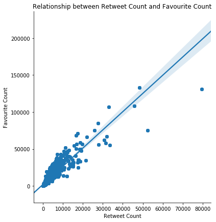

```python
sb.lmplot(data = df_master_file, x = 'retweet_count', y = 'favorite_count', size = 6);
plt.xlabel('Retweet Count');
plt.ylabel('Favourite Count');
plt.title('Relationship between Retweet Count and Favourite Count');
```

### Insight Two : Most Common Dog Types.

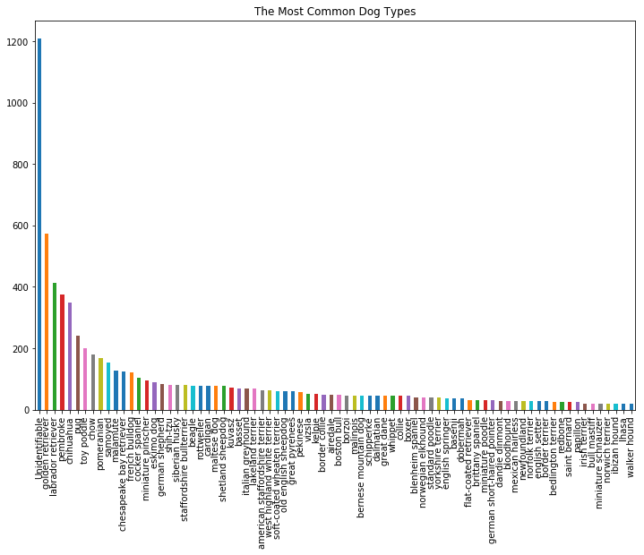

```python
most_rated_breed = df_master_file.groupby('dog_type').filter(lambda x: len(x) >= 20);
most_rated_breed['dog_type'].value_counts().plot(kind = 'bar', figsize = (12,8));
plt.title('The Most Common Dog Types');
```

### Insight Three : Relationship between Dog Stages And Retweets.

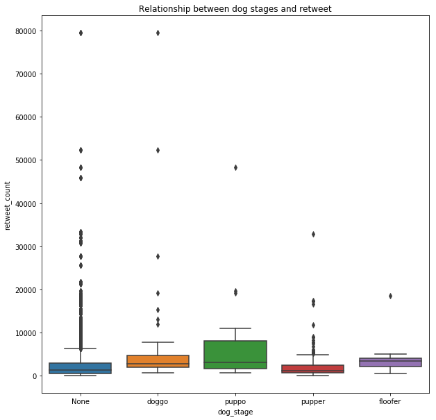

```python
plt.figure(figsize = (10,10));
g = sb.boxplot(data = df_master_file, x = 'dog_stage', y = 'retweet_count');
g.axes.set_title('Relationship between dog stages and retweet');
```